# We can measure how much Edmonton property *should* be tax-exempt. We cannot say which.

This notebook pulls the best data any member of the public can get about Edmonton property tax, and shows that it is enough to **size** the city's tax-exempt property to within a few percent — and **not** enough to name a single exempt parcel.

That is not a complaint about data quality. It is a structural property of what gets published, and the notebook works out exactly where the wall is.

## What it does, in one paragraph

Edmonton's published assessment roll lists every property and its assessed value. Almost none of it is flagged tax-exempt. But Edmonton also *files* its taxable assessment with the Province of Alberta, and that filed number is smaller than the roll. The difference is property the City assesses but does not tax. We can locate most of it by zoning. We cannot identify it, and the last section proves that with a construction rather than an argument.

## Self-contained

**Runtime** is dominated by two things: a ~80 MB CSV download the first time, and a 440,000-point spatial join (about a minute). Re-runs use the cache.

```
pip install pandas geopandas requests certifi openpyxl matplotlib
```

**A caveat about provenance.** This notebook deliberately reimplements its arithmetic inline instead of importing a pipeline, so it can be read and run on its own. The cost of that choice is drift: it hardcodes a handful of definitions (class names, zone codes, one published mill rate) that live authoritatively elsewhere. Each one is flagged **`ASSUMPTION`** where it appears, with what would falsify it.

```python
import base64
import io
import json
import os
import re
import ssl
import sys
import urllib.request
from pathlib import Path

import certifi
import matplotlib.pyplot as plt
import matplotlib.ticker as mticker
import numpy as np
import pandas as pd

# Some networks (and some older Linux CA bundles) fail on hosts whose
# certificate chains to a root issued after the bundle was built. certifi's
# bundle is current, so it is used explicitly rather than relying on the
# system store — this is a real failure mode, not a precaution.
SSL_CTX = ssl.create_default_context(cafile=certifi.where())

# open.alberta.ca returns 403 to urllib's default User-Agent. Identifying the
# client is required to get a response at all, not politeness.
UA = "Mozilla/5.0 (compatible; edmonton-exemption-notebook/1.0)"

CACHE = Path(os.environ.get("EXEMPTION_NB_DATA", "./exemption_data")).resolve()
CACHE.mkdir(parents=True, exist_ok=True)


def read_url(url: str, timeout: int = 300) -> bytes:
    req = urllib.request.Request(url, headers={"User-Agent": UA})
    with urllib.request.urlopen(req, context=SSL_CTX, timeout=timeout) as r:
        return r.read()


def fetch(url: str, name: str) -> Path:
    """Download once into CACHE; reuse thereafter. Returns the local path."""
    dest = CACHE / name
    if dest.exists() and dest.stat().st_size > 0:
        print(f"  cached  {name}  ({dest.stat().st_size / 1e6:.1f} MB)")
        return dest
    print(f"  fetching {name} …", end="", flush=True)
    dest.write_bytes(read_url(url))
    print(f" {dest.stat().st_size / 1e6:.1f} MB")
    return dest


def show(fig, alt: str) -> None:
    """Display a figure carrying real alt text.

    `plt.show()` emits a bare <img> with no alt attribute, so every chart is
    invisible to a screen reader and to anyone whose images fail to load. The
    figure is embedded by hand instead, with a description that states what the
    chart SAYS rather than what it depicts.
    """
    from IPython.display import HTML, display  # noqa: PLC0415

    buf = io.BytesIO()
    fig.savefig(buf, format="png", dpi=110, facecolor=fig.get_facecolor())
    plt.close(fig)
    encoded = base64.b64encode(buf.getvalue()).decode("ascii")
    display(HTML(f'<img alt="{alt}" src="data:…">'))


# ⚠️ THIS REPORT IS A SNAPSHOT, and the published page has to say so on its own
# face — it is the artifact that gets handed to someone, usually without the
# index page that would otherwise date it. Two of these four carried NO date at
# all until 2026-08-29.
#
# FIRST_MEASURED is when the finding was made and does NOT change on re-run.
# _STAMPED_AT is when this page was last re-executed against live data. Both are
# shown: "first found on" and "still true today" are different claims and a
# reader needs each. Imports are aliased and local to this block so it can be
# pasted into any of these notebooks unchanged.
import datetime as _dt

from IPython.display import Markdown as _Md, display as _disp

FIRST_MEASURED = "2026-08-26"
_STAMPED_AT = _dt.datetime.now(_dt.timezone.utc)

_disp(_Md(
    f"**Snapshot.** Finding first measured **{FIRST_MEASURED}**; this page "
    f"re-executed against live data **{_STAMPED_AT:%Y-%m-%d}** (UTC). "
    f"Nothing re-runs these on a schedule — re-execute before citing a figure."))

CHECKS: list[tuple[bool, str]] = []


def check(ok: bool, claim: str) -> None:
    """Record a structural invariant. Reported together at the end.

    These are claims that must hold for ANY vintage of this data — not the
    values themselves, which move every time Edmonton refreshes the roll —
    except the exempt-flag claim in §3, which is meant to fail when the
    publisher fixes the flag.
    """
    CHECKS.append((bool(ok), claim))
    print(f"  [{'PASS' if ok else 'FAIL'}] {claim}")


print(f"cache: {CACHE}")
```

**Snapshot.** Finding first measured **2026-08-26**; this page re-executed against live data **2026-09-23** (UTC). Nothing re-runs these on a schedule — re-execute before citing a figure.

```
cache: /tmp/tmp.gvgCJDbOHA/e
```

## 1. Source one — Edmonton's assessment roll

One row per tax account, published on Edmonton's open data portal. This is the most detailed property-level data the City releases: every account, its assessed value, its assessment class, and its coordinates.

```python
ROLL_URL = (
    "https://data.edmonton.ca/api/views/q7d6-ambg/rows.csv?accessType=DOWNLOAD"
)
roll_path = fetch(ROLL_URL, "assessment_roll.csv")

roll = pd.read_csv(roll_path, low_memory=False).rename(
    columns={
        "Account Number": "account",
        "Neighbourhood": "hood",
        "Assessed Value": "assessed",
        "Assessment Class 1": "class_1",
        "Assessment Class 2": "class_2",
        "Assessment Class 3": "class_3",
        "Assessment Class % 1": "pct_1",
        "Assessment Class % 2": "pct_2",
        "Assessment Class % 3": "pct_3",
        "Latitude": "lat",
        "Longitude": "lon",
    }
)

print(f"\naccounts published:   {len(roll):,}")
print(f"total assessed value: ${roll['assessed'].sum() / 1e9:,.1f}B")

# A property can be split across up to three assessment classes, each with a
# percentage. Any class total has to apportion by those percentages or a
# mixed-use building lands entirely in whichever class happens to be first.
SLOTS = [("class_1", "pct_1"), ("class_2", "pct_2"), ("class_3", "pct_3")]

pct_total = sum(roll[p].fillna(0) for _, p in SLOTS)
off_100 = ((pct_total - 100).abs() > 0.5) & roll["assessed"].notna()
print(f"rows whose class percentages miss 100: {int(off_100.sum()):,}")

# Zero/null assessed value carries no tax and no information here. Dropping it
# cannot move a ratio; it is arithmetic hygiene, not a policy choice.
dropped = roll["assessed"].isna() | (roll["assessed"] == 0)
roll = roll[~dropped].copy()
roll["assessed"] = roll["assessed"].astype(float)
print(f"dropped null/zero value rows: {int(dropped.sum()):,}")

check(roll["account"].is_unique, "one row per account — no duplicate billing")
check(roll["lat"].notna().all() and roll["lon"].notna().all(),
      "every remaining property has coordinates (needed for the zoning join)")
```

```
  fetching assessment_roll.csv …
```

```
 79.6 MB
```

```
accounts published:   439,641
total assessed value: $238.4B
rows whose class percentages miss 100: 80
dropped null/zero value rows: 53
  [PASS] one row per account — no duplicate billing
  [PASS] every remaining property has coordinates (needed for the zoning join)
```

### The roll's own exemption flag is empty

Edmonton's assessment class vocabulary contains exactly one value that means "not taxed": `NONRES MUNICIPAL/RES EDUCATION`. If the roll were going to tell us which property is exempt, this is the column that would do it.

> **`ASSUMPTION`** — that this label is the roll's only exemption marker. It is falsified by any *other* class label carrying a zero municipal rate. The cell below prints the full class vocabulary so you can check.

```python
EXEMPT_LABEL = "NONRES MUNICIPAL/RES EDUCATION"

classes = sorted(
    set().union(*[set(roll[c].dropna().unique()) for c, _ in SLOTS])
)
print("every assessment class present in the roll:")
for c in classes:
    n = sum(int((roll[lc] == c).sum()) for lc, _ in SLOTS)
    print(f"  {c:34s} {n:>9,} slices")

# The label can appear in any of the three class slots — a property can be
# PARTLY exempt — so the value is apportioned by percentage like every other
# class total here, rather than counting whole properties.
flagged_rows = np.zeros(len(roll), dtype=bool)
flagged_value = 0.0
for label_col, pct_col in SLOTS:
    m = (roll[label_col] == EXEMPT_LABEL).to_numpy()
    flagged_rows |= m
    flagged_value += (roll.loc[m, "assessed"] * roll.loc[m, pct_col].fillna(0) / 100).sum()

print(f"\nproperties with any exempt-flagged share: {int(flagged_rows.sum()):,} "
      f"of {len(roll):,}")
print(f"assessed value so flagged:               ${flagged_value:,.0f}")
print(f"share of the roll:                       "
      f"{100 * flagged_value / roll['assessed'].sum():.4f}%")
```

```
every assessment class present in the roll:
  COMMERCIAL                            23,386 slices
  DESIGNATED IND PROPERTIES                  1 slices
  FARMLAND                                 872 slices
  MA DERELICT RESIDENTIAL                  273 slices
```

```
  NONRES MUNICIPAL/RES EDUCATION             3 slices
  OTHER RESIDENTIAL                      4,478 slices
  RESIDENTIAL                          411,955 slices

properties with any exempt-flagged share: 3 of 439,588
assessed value so flagged:               $7,602,150
share of the roll:                       0.0032%
```

**Read on the roll alone, Edmonton is a city with essentially no tax-exempt property.** A handful of accounts out of hundreds of thousands.

That is obviously false. Edmonton has a university, a legislature, hospitals, federal land, hundreds of parks, dozens of schools and places of worship. All of it is on the roll, assessed, and — as far as the published columns go — indistinguishable from a taxable warehouse.

So the roll cannot answer the question by itself. We need a second source that knows the answer in aggregate.

## 2. Source two — what Edmonton filed with the Province

Every Alberta municipality files an annual return with Municipal Affairs. The Province republishes them as the Financial Information Return (FIR). Schedule MR carries three sheets we need, per municipality:

| sheet | what it holds |
| --- | --- |
| `MR(1)-Tax Levy` | municipal tax levied, by class |
| `MR(2)-Assessment` | the assessment that levy was computed on |
| `MR(3)-Mill Rate` | the rates applied |

`MR(2)` is the number the roll cannot give us: Edmonton's own statement of its **taxable** assessment.

```python
FIR_PAGE = "https://open.alberta.ca/opendata/municipal-financial-and-statistical-data"

page = read_url(FIR_PAGE, timeout=120).decode("utf-8", "replace")

# The province publishes a full financial workbook per year, and — for the
# newest year — an early "tax rates" workbook that carries Schedule MR before
# the complete filing lands. Both are usable; the full one wins where both exist.
workbooks: dict[int, str] = {}
for url in set(re.findall(r'href="(https://open\.alberta\.ca/dataset/[^"]+)"', page)):
    m = re.search(r"/download/(\d{4})_(?:financial_year|tax_rates)\.xlsx$", url, re.I)
    if m:
        year = int(m.group(1))
        if year not in workbooks or "financial_year" in url.lower():
            workbooks[year] = url

FIR_YEAR = max(workbooks)
print(f"FIR years published: {min(workbooks)}–{max(workbooks)}")
print(f"using the newest:    {FIR_YEAR}")

fir_path = fetch(workbooks[FIR_YEAR], f"fir_{FIR_YEAR}.xlsx")
```

```
FIR years published: 2017–2026
using the newest:    2026
  fetching fir_2026.xlsx …
```

```
 0.2 MB
```

```python
import openpyxl  # noqa: E402  — only needed from here on

EDMONTON_CODE, EDMONTON_NAME = "0098", "EDMONTON"

# Column positions within Schedule MR, and the header text each must contain.
# Reading by position alone would silently return the wrong class if the
# Province ever reorders the sheet, so the header is verified first.
MR_COLUMNS = {5: "residential", 6: "farmland", 7: "non_residential",
              9: "machinery_equipment", 10: "other"}
MR_HEADER_EXPECT = {5: "residential", 6: "farmland", 7: "non-residential",
                    9: "machinery", 10: "other"}
SHEETS = {"MR(1)-Tax Levy": "levy", "MR(2)-Assessment": "assessment",
          "MR(3)-Mill Rate": "mill_rate"}

wb = openpyxl.load_workbook(fir_path, read_only=True, data_only=True)
fir: dict[str, dict[str, float]] = {}
for sheet, key in SHEETS.items():
    ws = wb[sheet]
    header = next(ws.iter_rows(min_row=2, max_row=2, values_only=True))
    for idx, expect in MR_HEADER_EXPECT.items():
        got = str(header[idx] or "").lower()
        if expect not in got:
            raise ValueError(
                f"{sheet} column {idx} reads {header[idx]!r}, expected {expect!r} "
                "— Schedule MR moved; do not read it blind"
            )
    row = next(
        r for r in ws.iter_rows(values_only=True)
        if any(isinstance(c, str) and c.strip().upper() == EDMONTON_NAME for c in r[:6])
    )
    if str(row[2]).strip() != EDMONTON_CODE:
        raise ValueError(f"{EDMONTON_NAME} found under code {row[2]!r}")
    fir[key] = {n: (None if row[i] is None else float(row[i]))
                for i, n in MR_COLUMNS.items()}
wb.close()

print(f"Edmonton's {FIR_YEAR} filing (municipality code {EDMONTON_CODE}):\n")
print(f"{'class':<22}{'taxable assessment':>22}{'levy':>20}{'rate':>10}")
for cls in MR_COLUMNS.values():
    a, lv, rt = fir["assessment"][cls], fir["levy"][cls], fir["mill_rate"][cls]
    print(f"{cls:<22}{'$' + format(a, ',.0f'):>22}"
          f"{'$' + format(lv, ',.0f'):>20}{rt:>10.4f}")
```

```
Edmonton's 2026 filing (municipality code 0098):

class                     taxable assessment                levy      rate
residential                 $160,372,669,990      $1,241,589,174    7.7419
farmland                         $64,037,506            $495,772    7.7419
non_residential              $43,985,676,319      $1,109,389,134   25.2216
machinery_equipment             $759,582,941                  $0    0.0000
other                        $19,017,428,050        $157,601,911    0.0000
```

### Proving `MR(2)` is the *taxable* base, not a gross roll total

The whole comparison rests on `MR(2)` being assessment-after-exemptions. The Province's three sheets prove it internally: if assessment × mill rate reproduces the levy, then that assessment is what the tax was actually computed on.

```python
for cls in ("residential", "non_residential"):
    a, rt, lv = fir["assessment"][cls], fir["mill_rate"][cls], fir["levy"][cls]
    calc = a * rt / 1000
    check(abs(calc - lv) / lv < 1e-4,
          f"{cls}: filed assessment x filed rate reproduces filed levy "
          f"({100 * (calc / lv - 1):+.4f}%)")
```

```
  [PASS] residential: filed assessment x filed rate reproduces filed levy (-0.0000%)
  [PASS] non_residential: filed assessment x filed rate reproduces filed levy (-0.0000%)
```

### Aligning Edmonton's classes to the Province's buckets

The two vocabularies are not identical, and this is the most fragile joint in the notebook.

`RESIDENTIAL`, `FARMLAND` and the non-residential classes map straightforwardly. Apartment buildings (`OTHER RESIDENTIAL` on the roll, its own slightly higher municipal rate) have **no slot in Schedule MR at all** — the Province's columns are Residential / Farmland / Non-Residential / M&E / Other. Edmonton files them under **Other**, whose header literally reads *"Other (including annexed, vacant, total minimum tax, etc.)"*.

That mapping is *derived, not labelled* — the cell below checks it the only way available: the rate implied by the Province's own numbers (`levy ÷ assessment`) against Edmonton's published apartment rate. If they match, that is what is in the bucket.

> **`ASSUMPTION`** — the published municipal rate below is typed in from Edmonton's rate bylaw for this roll year. It is the one hand-entered number in the notebook, and it is used *only* for this validation, never in a total.

```python
PUBLISHED_APARTMENT_RATE = 8.2064  # Edmonton "Other Residential" municipal, 2026

implied = 1000 * fir["levy"]["other"] / fir["assessment"]["other"]
print(f"rate implied by Edmonton's FIR filing for 'Other': {implied:.4f}")
print(f"Edmonton's published apartment rate:               {PUBLISHED_APARTMENT_RATE:.4f}")
print(f"difference:                                        {100 * (implied / PUBLISHED_APARTMENT_RATE - 1):+.2f}%")

check(abs(implied / PUBLISHED_APARTMENT_RATE - 1) < 0.02,
      "the Province's 'Other' bucket bills at Edmonton's apartment rate "
      "— apartments are what is in it")

# The residential and non-residential rates should match Edmonton's published
# rates exactly, which is the cheapest possible confirmation that this filing
# and this roll describe the same tax year.
print(f"\nfiled residential rate:     {fir['mill_rate']['residential']:.4f}")
print(f"filed non-residential rate: {fir['mill_rate']['non_residential']:.4f}")
```

```
rate implied by Edmonton's FIR filing for 'Other': 8.2872
Edmonton's published apartment rate:               8.2064
difference:                                        +0.99%
  [PASS] the Province's 'Other' bucket bills at Edmonton's apartment rate — apartments are what is in it

filed residential rate:     7.7419
filed non-residential rate: 25.2216
```

```python
# ASSUMPTION — this map is Edmonton's class vocabulary as of this roll. A new
# class label appearing on the roll would be silently unmapped, so it raises.
CLASS_TO_FIR = {
    "RESIDENTIAL": "residential",
    "OTHER RESIDENTIAL": "other",
    "FARMLAND": "farmland",
    "COMMERCIAL": "non_residential",
    "MA DERELICT RESIDENTIAL": "non_residential",
    "DESIGNATED IND PROPERTIES": "non_residential",
    EXEMPT_LABEL: None,
}
unmapped = set(classes) - set(CLASS_TO_FIR)
if unmapped:
    raise KeyError(f"unmapped assessment class(es): {sorted(unmapped)}")

BUCKETS = ["residential", "other", "non_residential", "farmland"]
for b in BUCKETS:
    roll[f"av_{b}"] = 0.0
for label_col, pct_col in SLOTS:
    share = roll[pct_col].fillna(0) / 100
    for label, bucket in CLASS_TO_FIR.items():
        if bucket is None:
            continue
        m = roll[label_col] == label
        roll.loc[m, f"av_{bucket}"] += roll.loc[m, "assessed"] * share[m]

apportioned = roll[[f"av_{b}" for b in BUCKETS]].to_numpy().sum()
check(apportioned <= roll["assessed"].sum() * 1.0001,
      "apportioning into buckets does not create assessed value")
```

```
  [PASS] apportioning into buckets does not create assessed value
```

## 3. The gap

Everything is now in the same units: assessed dollars, in the Province's buckets, for the same year. What the roll says we could tax, against what Edmonton says it did tax.

```python
gaps = pd.DataFrame(
    [
        {
            "bucket": b,
            "roll": roll[f"av_{b}"].sum(),
            "filed": fir["assessment"][b],
        }
        for b in BUCKETS
    ]
).set_index("bucket")
gaps["gap"] = gaps["roll"] - gaps["filed"]
gaps["gap_pct"] = 100 * (gaps["roll"] / gaps["filed"] - 1)

pd.set_option("display.float_format", lambda v: f"{v:,.0f}")
print(gaps[["roll", "filed", "gap"]].to_string())
print(f"\ntotal assessed value on the roll that Edmonton does not tax: "
      f"${gaps['gap'].sum() / 1e9:,.2f}B")
print(f"value the roll actually flags as exempt:                      "
      f"${flagged_value / 1e9:,.4f}B")
print(f"\nthe flag accounts for {100 * flagged_value / gaps['gap'].sum():.2f}% of it.")

check((gaps["gap"] > 0).all(),
      "every class taxes LESS than the roll carries — exemptions only subtract")
# The one claim here that is SUPPOSED to fail: if Edmonton starts populating
# the exempt flag, this page's headline is wrong and the monthly recheck must
# say so. Measured at ~0.05% on 2026-08-26; 1% leaves room for drift, not a fix.
check(flagged_value < 0.01 * gaps["gap"].sum(),
      "the roll's exempt flag accounts for under 1% of the untaxed value")
```

```
                           roll           filed           gap
bucket
residential     162,335,306,865 160,372,669,990 1,962,636,875
other            23,022,884,727  19,017,428,050 4,005,456,677
non_residential  52,963,195,361  43,985,676,319 8,977,519,042
farmland             69,708,715      64,037,506     5,671,209

total assessed value on the roll that Edmonton does not tax: $14.95B
value the roll actually flags as exempt:                      $0.0076B

the flag accounts for 0.05% of it.
  [PASS] every class taxes LESS than the roll carries — exemptions only subtract
  [PASS] the roll's exempt flag accounts for under 1% of the untaxed value
```

**Residential is nearly explained; the other two are not.** Residential land is barely exempt anywhere — a house is a house — so the roll and the filing almost agree. Apartments and non-residential diverge by about a fifth.

That shape is itself the first piece of evidence: whatever is missing is concentrated in exactly the classes where institutional, public and non-profit property lives.

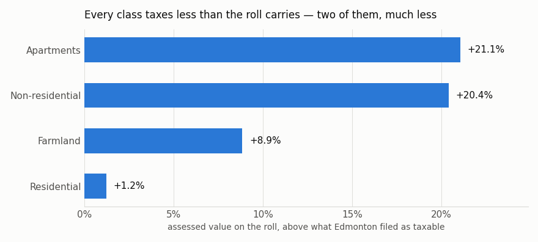

```python
# --- chart 1 ---------------------------------------------------------------
# Form: magnitude across four unordered categories -> bar. One series, so no
# legend; the title names the measure. Values are direct-labelled because
# reading a percentage off a gridline is worse than reading the number.
SURFACE, INK, INK_MUTED = "#fcfcfb", "#0b0b0b", "#52514e"
BLUE, ORANGE = "#2a78d6", "#eb6834"   # validated categorical slots 1 and 2
GRID = "#dcdcd8"

LABELS = {"residential": "Residential", "other": "Apartments",
          "non_residential": "Non-residential", "farmland": "Farmland"}

fig, ax = plt.subplots(figsize=(8, 3.6), facecolor=SURFACE)
ax.set_facecolor(SURFACE)
order = gaps.sort_values("gap_pct", ascending=True)
bars = ax.barh([LABELS[b] for b in order.index], order["gap_pct"],
               color=BLUE, height=0.55)
for rect, v in zip(bars, order["gap_pct"]):
    ax.text(rect.get_width() + 0.4, rect.get_y() + rect.get_height() / 2,
            f"+{v:.1f}%", va="center", ha="left", color=INK, fontsize=10)

ax.set_xlim(0, order["gap_pct"].max() * 1.18)
ax.xaxis.set_major_formatter(mticker.PercentFormatter(decimals=0))
ax.set_xlabel("assessed value on the roll, above what Edmonton filed as taxable",
              color=INK_MUTED, fontsize=9)
ax.set_title("Every class taxes less than the roll carries — two of them, much less",
             color=INK, fontsize=11, loc="left", pad=12)
ax.grid(axis="x", color=GRID, linewidth=0.6)
ax.set_axisbelow(True)
for s in ("top", "right", "left"):
    ax.spines[s].set_visible(False)
ax.spines["bottom"].set_color(GRID)
ax.tick_params(colors=INK_MUTED, length=0)
plt.tight_layout()
show(fig, "Bar chart of how far each assessment class's roll value exceeds what "
          "Edmonton filed as taxable. Residential is close to matching at about 1 "
          "percent, while apartments and non-residential each stand about 21 percent "
          "above the filed base, concentrating the unexplained value in the two classes "
          "where institutional and non-profit property sits.")
```